# Markov Chains

This paper has three sections. The first section uses simulation to develop an intuitive understanding of the ideas behind Markov Chains; the second section looks at some of the mathematics used to represent the problem, leading to the standard eigenvector representation and the final section describes an idea to use Markov Chains together with a probability distribution model of social mobility to predict long term "social class" proportions.

## Intuition

### Single State Markov Chain - The Law of Large Numbers

The relative frequency/experimental probability gets closer the theoretical probability as the number of trials increases. So, if event A has a given probability, then as the number of trials increases the proportion of times event A occurs gets closer to the probability of A. So a single state Markov Chain has "long term behaviour".

### Simulation:

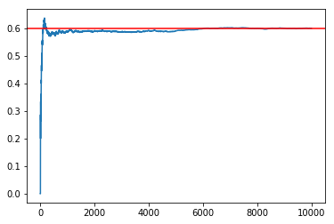

```python
import matplotlib.pyplot as plt
from random import uniform

# Setting probabilities and parameters

pA = 0.6
ntrails = 10000
probs = []
count_trials = 0
count_success = 0

# performing simulations

for i in range(0,ntrails):
    count_trials = count_trials + 1
    var = uniform(0,1)
    if var < pA:
        count_success = count_success + 1
    probs.append(count_success/count_trials)

# plotting results

plt.plot(probs)
plt.axhline(y=pA, color='r', linestyle='-')
plt.show()
```

### Multi State Markov Chains

If we have a system that has multiple "states" and the probabilities change depending on the current state, is there long term behaviour/does it matter what state the system starts in?

[figure not shown]

### Simulation:

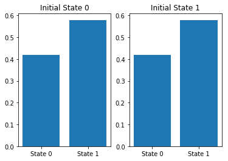

```python
# state dependent simulation function

def markov_sim(state,p00,p10,ntrails):
    count_s0 = 0
    count_s1 = 0
    for i in range(0,ntrails):
        if state == 0:
            count_s0 = count_s0 + 1
        elif state == 1:
            count_s1 = count_s1 + 1
        var = uniform(0,1)
        if state == 0:
            if var < p00:
                state = 0
            else:
                state = 1
        elif state == 1:
            if var < p10:
                state = 0
            else:
                state = 1
    return [count_s0, count_s1]

# Setting probabilities and parameters

ntrials = 10000
p00 = 0.3
p10 = 0.5
count_init_S0 = markov_sim(1,p00,p10,ntrials)
count_init_S0 = [x / ntrials for x in count_init_S0]
num_cols = range(len(count_init_S0))
plt.subplot(1, 2, 1)
plt.bar(['State 0', 'State 1'],count_init_S0)
plt.title('Initial State 0')

count_init_S1 = markov_sim(1,p00,p10,ntrials)
count_init_S1 = [x / ntrials for x in count_init_S1]
plt.subplot(1, 2, 2)
plt.bar(['State 0', 'State 1'],count_init_S1)
plt.title('Initial State 1')

plt.show()
```

## Some of the Maths

The standard approach is to represent the probabilities as a transition matrix. E.g.

$$ P = \begin{pmatrix} p00 & p01 \\ p10 & p11 \end{pmatrix} $$

Where $$ pij = P(state(n+1) = i|state(n) = j) $$

Given this definition P to the power of n can be interpreted as

$$P^n = \begin{pmatrix} P(s(n) = 0| s(0) = 0) & P(s(n) = 0| s(0) = 1) \\ P(s(n) = 1| s(0) = 0) & P(s(n) = 1| s(0) = 1) \end{pmatrix} $$

So the first column is the probability of being in state 0 or 1 at the nth step given the system started in state 0 and the second is the probability of being in state 0 or 1 at the nth step given the system started in state 1. If this is true you would expect the columns of P to the power of n to match the proportions in the simulation above for large n. This result is verified by simultation and proved mathematically bellow:

### Simulation:

Raising P to the power of n gives the same proportions as the previous simulation

```python
# importing numpy
import numpy as np

P = np.array([[p00, p10],[1-p00, 1-p10]])
print("Transition Matrix P:\n")
print(P)
Pn = np.linalg.matrix_power(P, ntrials)
print("\nTransition Matrix P to the Power of n:\n")
print(Pn)
```

```
Transition Matrix P:

[[ 0.3  0.5]
 [ 0.7  0.5]]

Transition Matrix P to the Power of n:

[[ 0.41666667  0.41666667]
 [ 0.58333333  0.58333333]]
```

### Proof

Use induction, take n = 0 as initial state, then true for n = 1 by definition. Assuming true for n and prove true for n + 1.

$$P^{n+1} = P \times P^n = \begin{pmatrix} p00 & p01 \\ p10 & p11 \end{pmatrix} \times \begin{pmatrix} P(s(n) = 0| s(0) = 0) & P(s(n) = 0| s(0) = 1) \\ P(s(n) = 1| s(0) = 0) & P(s(n) = 1| s(0) = 1) \end{pmatrix}$$

Seeing as pij = P(state = i|state = j) for every point in the chain, pij can be taken as P(s(n+1) = i|s(n) = j). Using this in the above formulation gives:

$$P^{n+1} = \begin{pmatrix} P(s(n+1)=0|s(n)=0) & P(s(n+1)=0|s(n)=1) \\ P(s(n+1)=1|s(n)=0) & P(s(n+1)=1|s(n)=1) \end{pmatrix} \times \begin{pmatrix} P(s(n) = 0| s(0) = 0) & P(s(n) = 0| s(0) = 1) \\ P(s(n) = 1| s(0) = 0) & P(s(n) = 1| s(0) = 1) \end{pmatrix}$$

The top left element is

$$P(s(n+1)=0|s(n)=0) \times P(s(n) = 0| s(0) = 0) + P(s(n+1)=0|s(n)=1) \times P(s(n) = 1| s(0) = 0)$$

Starting in state 0 and being at state 0 for step n+1 via state n can happen in two ways:

- step 0 state 0; step n state 0; step n+1 state 0
- step 0 state 0; step n state 1; step n+1 state 0

So the top left element is equal to P(s(n+1)=0|s(0)=0)

Similar arguements for the remaining elements gives:

$$P^{n+1} = \begin{pmatrix} P(s(n+1) = 0| s(0) = 0) & P(s(n+1) = 0| s(0) = 1) \\ P(s(n+1) = 1| s(0) = 0) & P(s(n+1) = 1| s(0) = 1) \end{pmatrix} $$

### Eigenvector Representation

It can be proved, in most cases, that P tends to a limit as n tends to infinity. These notes contain far more details (http://www.statslab.cam.ac.uk/~rrw1/markov/M.pdf). I have assumed this as a starting point.

$$P^{n} \to P^{\infty}$$ as $$n \to \infty$$

Then for large n

$$P^{n+1} \approx P^{n} \implies P \times P^{n} \approx P^{n}$$

Taking the limit

$$P \times P^{\infty} = P^{\infty}$$

$$ \implies \text{the columns of } P^{\infty} \text{are eigen vectors of P with an eigenvalue of 1}$$

So the long term behaviour of the system can be found by calculating the eigenvectors with an eigenvalue of 1. The simulation below shows that the eigen vector of P with with eigen value of 1 gives the same result as the previous two simulations to find the long term behaviour of the system.

### Simulation:

```python
Peig = np.linalg.eig(P)
# printing first eigenvalue/vector
print("First set of eigenvectors/values:")
print("Eigenvalue:")
print(Peig[0][0])
print("Eigenvector (normalised to add to 1):")
print(Peig[1][:,0]/sum(Peig[1][:,0]))
# printing second eigenvalue/vector
print("Second set of eigenvectors/values:")
print("Eigenvalue:")
print(Peig[0][1])
print("Eigenvector (normalised to add to 1):")
print(Peig[1][:,1]/sum(Peig[1][:,1]))
```

```
First set of eigenvectors/values:
Eigenvalue:
-0.2
Eigenvector (normalised to add to 1):
[-inf  inf]
Second set of eigenvectors/values:
Eigenvalue:
1.0
Eigenvector (normalised to add to 1):
[ 0.41666667  0.58333333]
```

## Markov Model Based on a Social Mobility Probability Distributions

The following extract is from the BBC's "Great British Class" survey. For full details follow this link https://www.bbc.co.uk/labuk/experiments/the-great-british-class-survey

[figure not shown]

If the class you start a family in is largely dependent on the class you were born into, then the transistion from one generation to the next could be modelled as a Markov Chain. E.g.

[figure not shown]

Assumptions:

1. Families form a 2 to 2 relationship (two parent two children) across classes
2. Class types and quantity remain constant from generation to generation
3. Class you start a family in is largely dependent on the class you are born into

Assumption 1 & 2 seem questionable. For example the BBC survey discusses how class types have evolved over the years. The interpretation of the model would have to be along the lines of "if current trends continue"

## Collecting Data

Ideally, collect data from people who have started a family. Specifically what class do they belong to now and what class where they born into. Provided sufficient data could be collected, it would be possible to form probability distributions for each class (like those below) giving the probabilities of transitioning to each class. Still thinking/looking to see how feasible this is.

## Example Output Based on Dummy Data

Dummy data (Just set so that each vector adds to one).

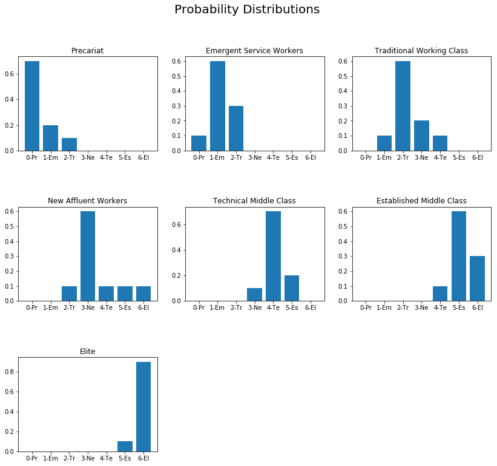

```python
skew = "pos"
if skew == "neg":
    s0_prob_dist = [0.7,0.2,0.1,0,0,0,0]
    s1_prob_dist = [0.3,0.6,0.1,0,0,0,0]
    s2_prob_dist = [0.1,0.2,0.6,0.1,0,0,0]
    s3_prob_dist = [0.1,0.1,0.1,0.6,0.1,0,0]
    s4_prob_dist = [0,0,0,0.2,0.7,0.1,0]
    s5_prob_dist = [0,0,0,0.1,0.2,0.6,0.1]
    s6_prob_dist = [0,0,0,0,0,0.1,0.9]
elif skew == "pos":
    s0_prob_dist = [0.7,0.2,0.1,0,0,0,0]
    s1_prob_dist = [0.1,0.6,0.3,0,0,0,0]
    s2_prob_dist = [0,0.1,0.6,0.2,0.1,0,0]
    s3_prob_dist = [0,0,0.1,0.6,0.1,0.1,0.1]
    s4_prob_dist = [0,0,0,0.1,0.7,0.2,0]
    s5_prob_dist = [0,0,0,0,0.1,0.6,0.3]
    s6_prob_dist = [0,0,0,0,0,0.1,0.9]

fig = plt.figure(figsize=(14,12))
fig.suptitle('Probability Distributions', fontsize=20)
fig.subplots_adjust(hspace=0.6)
ax = fig.add_subplot(3, 3 ,1)
ax.bar(['0-Pr','1-Em','2-Tr','3-Ne','4-Te','5-Es','6-El'],s0_prob_dist)
ax.title.set_text('Precariat')
ax = fig.add_subplot(3, 3, 2)
ax.bar(['0-Pr','1-Em','2-Tr','3-Ne','4-Te','5-Es','6-El'],s1_prob_dist)
ax.title.set_text('Emergent Service Workers')
ax = fig.add_subplot(3, 3, 3)
ax.bar(['0-Pr','1-Em','2-Tr','3-Ne','4-Te','5-Es','6-El'],s2_prob_dist)
ax.title.set_text('Traditional Working Class')
ax = fig.add_subplot(3, 3, 4)
ax.bar(['0-Pr','1-Em','2-Tr','3-Ne','4-Te','5-Es','6-El'],s3_prob_dist)
ax.title.set_text('New Affluent Workers')
ax = fig.add_subplot(3, 3, 5)
ax.bar(['0-Pr','1-Em','2-Tr','3-Ne','4-Te','5-Es','6-El'],s4_prob_dist)
ax.title.set_text('Technical Middle Class')
ax = fig.add_subplot(3, 3, 6)
ax.bar(['0-Pr','1-Em','2-Tr','3-Ne','4-Te','5-Es','6-El'],s5_prob_dist)
ax.title.set_text('Established Middle Class')
ax = fig.add_subplot(3, 3, 7)
ax.bar(['0-Pr','1-Em','2-Tr','3-Ne','4-Te','5-Es','6-El'],s6_prob_dist)
ax.title.set_text('Elite')
fig
```

Forming transition matrix and calculating the eigenvector with an eigenvalue of 1

```python
# importing numpy
import numpy as np

# forming probability matrix
P = np.array([s0_prob_dist,
              s1_prob_dist,
              s2_prob_dist,
              s3_prob_dist,
              s4_prob_dist,
              s5_prob_dist,
              s6_prob_dist])
P = np.transpose(P)

Pn = np.linalg.matrix_power(P, ntrials)
print("P to the power of n\n")
print(Pn)

eval,evec = np.linalg.eig(P)
norm_evec = evec[:,0]/sum(evec[:,0])

print("\nEigenvector (normalised to add to 1):\n")
print(norm_evec)
```

```
P to the power of n

[[ 0.00082372  0.00082372  0.00082372  0.00082372  0.00082372  0.00082372
   0.00082372]
 [ 0.00247117  0.00247117  0.00247117  0.00247117  0.00247117  0.00247117
   0.00247117]
 [ 0.00823723  0.00823723  0.00823723  0.00823723  0.00823723  0.00823723
   0.00823723]
 [ 0.0247117   0.0247117   0.0247117   0.0247117   0.0247117   0.0247117
   0.0247117 ]
 [ 0.08237232  0.08237232  0.08237232  0.08237232  0.08237232  0.08237232
   0.08237232]
 [ 0.21416804  0.21416804  0.21416804  0.21416804  0.21416804  0.21416804
   0.21416804]
 [ 0.66721582  0.66721582  0.66721582  0.66721582  0.66721582  0.66721582
   0.66721582]]

Eigenvector (normalised to add to 1):

[ 0.00082372  0.00247117  0.00823723  0.0247117   0.08237232  0.21416804
  0.66721582]
```

### Plot Predictions Against Data in the BBC Report

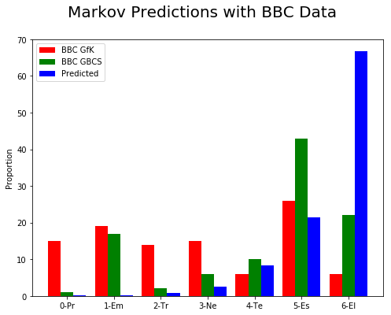

```python
# Data from BBC report
bbc_GfK_prop = [15,19,14,15,6,26,6]
bbc_GBCS_prop = [1,17,2,6,10,43,22]
# predicted percentages
pred_prop = 100*norm_evec
# plotting data
plt.clf()
plt.cla()
plt.close()

N = 7
ind = np.arange(N)  # the x locations for the groups
width = 0.27       # the width of the bars


fig = plt.figure(figsize=(8,6))
fig.suptitle('Markov Predictions with BBC Data', fontsize=20)
ax = fig.add_subplot(111)

rects1 = ax.bar(ind, bbc_GfK_prop, width, color='r')
zvals = [1,2,3]
rects2 = ax.bar(ind+width, bbc_GBCS_prop, width, color='g')
kvals = [11,12,13]
rects3 = ax.bar(ind+width*2, pred_prop, width, color='b')
ax.legend( (rects1[0], rects2[0], rects3[0]), ('BBC GfK', 'BBC GBCS', 'Predicted') )

ax.set_ylabel('Proportion')
ax.set_xticks(ind+width)
ax.set_xticklabels( ('0-Pr','1-Em','2-Tr','3-Ne','4-Te','5-Es','6-El') )

fig
```

### Similar Ideas

The following papers follow similar ideas

1. https://www.researchgate.net/publication/315059087_Intergeneration_Social_Mobility_as_a_Markov_Process
2. https://www.ssc.wisc.edu/~jmontgom/socialmobility.pdf

Paper 2 uses income quintiles to describe class which would get around the problem of class types changing, paper 1 considers 3 classes

### Things to do:

- Think of way to obtain data
- Use data to check the validity of the first assumption
- Read through similar papers thoroughly
- Read through Markov notes thoroughly

### Other interesting applications:

- Googles page rank algorithm http://blog.kleinproject.org/?p=280
- Number of articles giving examples of Markov Chains applied to Information Theory, Text Prediction and Computer Performance http://langvillea.people.cofc.edu/MCapps7.pdf